# Unit 3: On Tools and Algorithms

In the previous unit we got straight into general programming basics as well as specifics with Julia. We now know basic syntax, variables, conditional statements, loops, functions, and more. We spoke about bits, bytes, and representation of integers on a computer. In terms of tools we used Jupyter and the REPL.

In this unit we’ll get a taste for basic mathematical analysis of algorithms and quantification of behavior and performance. We’ll also deal with more extensive tools including Git and GitHub, Visual Studio Code (IDE), and basic Unix command line.

We’ll start with tooling and then move onto a basic demonstrations of the fact that the performance of algorithms can be analyzed mathematically.

# 1 More tools

We now spend more time on “tools”, namely,

- Unix command line
- Git and GitHub
- The Visual Studio Code IDE

## 1.1 Unix command line

An [operating system](https://en.wikipedia.org/wiki/Operating_system) is software that manages the other software and hardware of the computer. It manages:

- Files
- Computer memory (RAM)
- Running programs, processes (tasks), and sometimes threads within a task
- Input/Output
- Networking
- More …

This includes low level interfaces between the running programs and hardware, as well as its own “programs” for interfacing and managing the system (e.g. graphical user interface for files, and importantly for us the **shell**).

Unix is a classic operating system still very much in use today. Mac’s operating system [macOS](https://en.wikipedia.org/wiki/MacOS) is based on Unix. Similarly, Linux is a Unix based system. The most popular desktop family of operating systems, Windows is not Unix based.

Our focus is on the **shell**, or **command line interface** which allows to execute simple and complicated tasks via command line. In Windows this is called the “command line”. You can watch this (one of many) [video tutorial series](https://www.youtube.com/watch?v=MBBWVgE0ewk&list=PL6gx4Cwl9DGDV6SnbINlVUd0o2xT4JbMu) about the windows command line. However, you are not required to build up “command line” knowledge as part of this course. Instead if you are a Windows user, we recommended you use [GitBash](https://gitforwindows.org/) which gives you “Unix command line emulation”. If you are a Mac user, you will simply run “Terminal”, and on Linux you will run “Shell”.

Note that when you run a Julia REPL, hitting `;` puts you in “shell mode” where the system’s default shell is present.

We won’t become shell experts but only learn to carry out a few basic tasks. Our main use case will be using Git source control software (see more below). For this, we’ll also learn about basic file manipulation commands and a few more tid bits will appear as needed. We assume you are familiar with the fact your system has files, and folders (directories). Here are more things to be aware of:

- `~` stands for the folder of your user.
- `/` stands for the root directory.
- `.` stands for the current directory (there is always the notion of the current directory for our process/program).
- `..` stands for the parent directory.

Key file navigation commands are:

- `ls` show files.
- `cd` change current directory.
- `pwd` print working directory.

Key file manipulation commands are (be careful!):

- `rm` remove.
- `rmdir` remove (empty directory).
- `cp` copy.
- `mv` move (also rename).

A few more useful commands (apps): * `echo` print to screen (can be used as part of a shell script). * `cat` print a text file. * `head` print with first 10 lines of a text file * `tail` print with last 10 lines of a text file * `diff` compare two files line by line * `grep` search within a file. * `vim` and `emacs` text editors

Commands work well with wildcards/regular expressions. A very common one is `*`.

Output of commands can be **piped** into other commands using `|`, similarly it can be redirected into file with `>` or `>>` for appending.

There are some commands dealing with users and permissions (we won’t cover unless needed):

- `chmod` change permissions of a file.
- `whoami` who you are just in case you aren’t sure.
- `sudo` super user do.

There are some commands dealing with processes:

- `top` a task manager, shows running processes with cpu and memory utilization
- `kill` a process.
- `ps` see running processes.

Here are some tools for dealing with useful networking tasks:

- `curl` transfer data from a network with a variety of protocols supported
- `wget` transfer data from a network (recursive downloads supported)
- `ssh` cryptographic network protocol. Allows remote access to other machines.

Finally some useful development tools:

- `gcc` GNU compiler collection
- `make` useful tool for building applications
- `gdb` debugging tools

## 1.2 A Note on the Unix Philosophy

It can be hard to quantify good software design. An informative approach is the “Unix Philosophy”. This is summarized by Doug McIlroy (the inventor of Unix pipes) as:

- Make each program do one thing well. To do a new job, build afresh rather than complicate old programs by adding new features.
- Expect the output of every program to become the input to another, as yet unknown, program. Don’t clutter output with extraneous information. Avoid stringently columnar or binary input formats. Don’t insist on interactive input.
- Design and build software, even operating systems, to be tried early, ideally within weeks. Don’t hesitate to throw away the clumsy parts and rebuild them.
- Use tools in preference to unskilled help to lighten a programming task, even if you have to detour to build the tools and expect to throw some of them out after you’ve finished using them.

## 1.3 Git and GitHub

Working with software requires keeping track of versions and modifications. For this there is a set of best working practices that often depend on the task at hand.

The basic functionality of a version control system are:

- Keeping track of software history over time
- Being able to revert changes to a previous point in time (in case you break something important)
- Being able to make, track and merge experimental functionality, while keeping a “good” version unpolluted
- Keeping a remote backup of the source code in case of a disaster
- Allow teams of people to work in this way on a codebase without treading on each others toes (too much)

One very useful tool is Git. We will be using Git both via command line and via Visual Studio Code. Git interfaces with online platforms such as GitHub and GitLab. You may use GUI based applications for GitHub, such as [GitHub Desktop](https://desktop.github.com/).

For a review of commands see this [cheat sheet](https://www.atlassian.com/git/tutorials/atlassian-git-cheatsheet)

## 1.4 VS Code IDE

An IDE is an acronym for an “Integrated Development Environment”. The most basic development environment is simply a text file editor (such as vim) and somewhere to run the code (such as a Julia REPL). Software developers work with wide variety of such tools (with extensions to make coding a simpler task).

Features of an IDE that will make your life easier:

- Text Editor
- Source Code Navigation
- Syntax Highlighting
- Debugger
- Code Completion
- Version Control Integration
- Search Tools
- Language Support
- Code Linting

In this course we recommend using [VSCode](https://code.visualstudio.com/), an open source code editing tool made by Microsoft.

## 1.5 A Rough Field Guide to Software Licencing

There are a vast number of licencing arrangements for dealing with the use of software and the availability of source code for the software. Two broad classes to be aware of:

- Proprietary Software
- Free and Open Source Software

The source code for Proprietary Software is typically a closely guarded secret and unauthorised use can have severe legal consequences.

Free and Open source does not mean that source code can always be used in whatever fashion is desired. Many different philosophies around why a particular developer or organisation wishes to distribute source code need to be respected.

Open source code falls into three broad classes:

- Permissive Licence (e.g. BSD, MIT, Apache)
- Copyleft (e.g. GPL)
- Public Domain (e.g. CC0)

A rough summary is that Permissive Licences tend to be favorable for commercial use of derived software, Copyleft makes derived works free to redistribute, but they must also be Copyleft works, and Public Domain are the most free and can be used as desired. Again there can be severe legal consequences for misuse of derived works.

Examples of Software released under different licences:

- Proprietary - Microsoft Windows, MacOS, MATLAB
- Permissive - Julia (MIT), Python (PSFL), Android (Apache 2.0 for userspace, GPLv2 for kernel)
- Copyleft - Linux (GPLv2), R (GPLv2)
- Public Domain - BLAS, SQLite

# 2 Mathematical analysis of algorithms

As an illustration take sorting. Say we have a list of numbers and wish to sort it:

```julia
data = [65, 51, 32, 12, 23, 84, 68, 1]
sort!(data) #The '!' is part of the function name and indicates data is sorted in place
println("Sorted data: ", data)
```

```
Sorted data: [1, 12, 23, 32, 51, 65, 68, 84]
```

How would we implement such a sorting algorithm ourselves? One basic algorithm is called [bubble sort](https://en.wikipedia.org/wiki/Bubble_sort). Here is an implementation:

```julia
function bubble_sort!(a)
   n = length(a)
   for i in 1:n-1
      for j in 1:n-i
         if a[j] > a[j+1]
            (a[j], a[j+1]) = (a[j+1], a[j])
         end
      end
   end
   return a
end

bubble_sort!(data)
println("Sorted data (with buble sort): ", data)
```

```
Sorted data (with buble sort): [1, 12, 23, 32, 51, 65, 68, 84]
```

A key question when considering such an algorithm is **how fast does it run?** Other key questions include **how much memory does it use?**, as well as other questions. Such questions are often critical during the phase of algorithm design, and are later critical with algorithm or datastructure choice.

Later in the course you’ll use quite robust benchmarking tool such as BenchmarkTools.jl to empirically measure performance. But for now, lets empirically measure the performance of bubble sort. We also compare it to the in-built sorting algorithm.

```julia
using Random

function do_timing()
   data = [65, 51, 32, 12, 23, 84, 68, 1]
   println("Bubble sort on small data ($(length(data))):")
   @time bubble_sort!(data);

   data = [65, 51, 32, 12, 23, 84, 68, 1]
   println("In-built sort on small data ($(length(data))):")
   @time sort!(data);

   Random.seed!(0)
   data = rand(Int,10^4)
   println("Bubble sort on larger data ($(length(data))):")
   @time bubble_sort!(data);

   Random.seed!(0)
   data = rand(Int,10^4)
   println("In-built sort on larger data ($(length(data))):")
   @time sort!(data);
end
do_timing();
```

```
Bubble sort on small data (8):
  0.000000 seconds
In-built sort on small data (8):
  0.000000 seconds
Bubble sort on larger data (10000):
  0.044124 seconds
In-built sort on larger data (10000):
  0.000217 seconds (6 allocations: 86.328 KiB)
```

We can see that the in-built sort is much faster than our bubble sort.

Now obviously we can optimize our bubble sort a little bit, for example here is a slightly better version that has type specifications and [avoids bounds checking](https://docs.julialang.org/en/v1/devdocs/boundscheck/):

```julia
using Random
Random.seed!(0)

function slightly_faster_bubble_sort!(a::Vector{Int})::Vector{Int}
   n = length(a)
   for i in 1:n-1
      for j in 1:n-i
         @inbounds begin
            if a[j] > a[j+1]
               (a[j], a[j+1]) = (a[j+1], a[j])
            end
         end
      end
   end
   return a
end

#Let it run once to remove precompilation overhead
slightly_faster_bubble_sort!(rand(Int,100))

Random.seed!(0)
data = rand(Int,1000)

println("bubble sort ($(length(data))):")
@time bubble_sort!(data);

Random.seed!(0)
data = rand(Int,1000)

println("Slightly faster bubble sort ($(length(data))):")
@time slightly_faster_bubble_sort!(data);
```

```
bubble sort (1000):
  0.000484 seconds
Slightly faster bubble sort (1000):
  0.000370 seconds
```

Let’s investigate (empirically) a bit further:

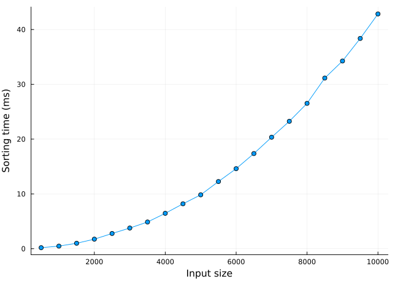

```julia
using Random, Plots
Random.seed!(0)

function do_timing()
   times = Vector{Float64}(undef, 0)
   n_range = 500 : 500 : 10^4
   for n in n_range
      data = rand(Int64, n)
      start_time = time_ns()
      bubble_sort!(data)
      end_time = time_ns()
      push!(times, Int(end_time - start_time) / 10^6) # time in milliseconds
   end
   return times, n_range
end

times, n_range = do_timing()

plot(n_range,times, xlabel="Input size", ylabel="Sorting time (ms)", legend = false, shape = :circle)
```

It appears that the running time grows quadratically with the input size! We can event try to fit a quadratic model using least squares for it:

[output not shown]

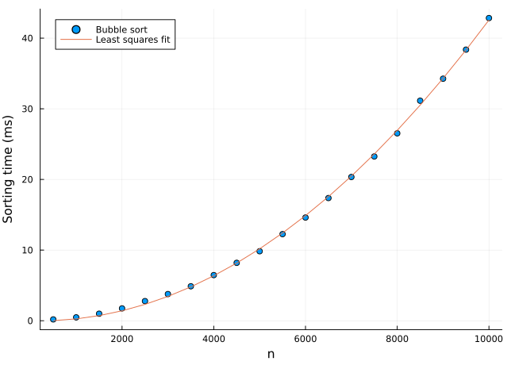

```julia
using DataFrames, GLM

data = DataFrame(X = Float64.(n_range), Y = times) #More on DataFrames later in the course
model = lm(@formula(Y ~ 1 + X + X^2), data) #This fits a linear model to the features 1, X, X^2
println(model)
predict_bubble_time(n) = coef(model)'*[1,n,n^2]
scatter(n_range, times,
   xlabel="n", label = "Bubble sort")
plot!(n_range, predict_bubble_time.(n_range),
   xlabel="n", ylabel="Sorting time (ms)",
   label = "Least squares fit", legend = :topleft)
```

Let’s see how this measured performance works for $30$ thousand observations and $50$ thousand observations:

```julia
Random.seed!(0)

function do_timing()
   data = rand(Int,3*10^4)
   prediction_seconds =  predict_bubble_time(3*10^4)/10^3
   print("Predicted time: $prediction_seconds \n Actual time:")
   @time bubble_sort!(data);

   data = rand(Int,5*10^4)
   prediction_seconds =  predict_bubble_time(5*10^4)/10^3
   print("\nPredicted time: $prediction_seconds \n Actual time:")
   @time bubble_sort!(data);
end
do_timing();
```

```
Predicted time: 0.3941117859418481
 Actual time:  0.871180 seconds

Predicted time: 1.1008908652989187
 Actual time:  2.808598 seconds
```

$$T(n) = \beta_0 + \beta_1 n + \beta_2 n^2.$$

If you run these experiments on your computer you’ll almost certainly get different $\beta$ values from the ones obtained here (the data is the same with a fixed seed but the hardware and instance of runs is different). Even on the same machine, different runs of the experiment will yield different $\beta$ values and hence a different $T(\cdot)$.

What if instead about worrying about the exact $T(\cdot)$ function we will focus on the most dominant term? Here we plot the running time first divided by $n^{1.8}$ and then by $n^{2}$.

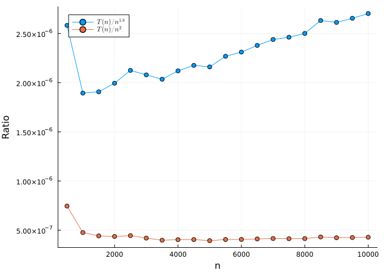

```julia
using LaTeXStrings

plot(n_range, times ./ n_range .^ (1.8),shape = :circle,label = L"T(n) / n^{1.8}")
plot!(n_range, times ./ n_range .^ 2,label = L"T(n) / n^{2}",
   xlabel = "n", ylabel = "Ratio",legend = :topleft,shape = :circle,)
```

The fact that it roughly goes to a constant when dividing by $n^2$ gives us an indication that,
$$T(n) \sim n^2.$$
The symbol ‘$\sim$’ means here that for some constant,
$$\lim_{n \to \infty} \frac{T(n)}{n^2} = C.$$

You can also interpret it as,
$$T(n) = C n^2 + o(n^2)$$
where $o(n^2)$ is some function such that when dividing by $n^2$ and taking $n \to \infty$, the ratio vanishes.

Now in computer science and the study of algorithms, you would often roughly say that,
$$T(n) = O(n^2).$$
Where the $O(\cdot)$ here follow [Big O notation](https://en.wikipedia.org/wiki/Big_O_notation). However to be more precise, some would interpret $T(n) = O(n^2)$ to mean that $T(n)$ `grows` not faster than $n^2$. Then it is also $O(n^3)$ and $O(n^4)$ and even $O(2^n)$ (exponential growth. However in this case we (so far empirically) see that the computation is at $O(n^2)$ and hence sometimes $\Theta(n^2)$ is used for this. However, as this is not a full algorithms course, we’ll just loosely write $O(n^2)$.

**But why is bubble sort an “$O(n^2)$ time complexity algorithm”?**

Well in this case we can inspect the algorithm and consider the number of comparisons taking place. To do so look at this “fragment of code”:

```
1: for i in 1:n-1                         #Outer loop
2:     for j in 1:n-i                     #Inner loop
3:        if a[j] > a[j+1]                #Comparison
4:            a[j], a[j+1] = a[j+1], a[j] #Switch
```

It is essentially the heart of the bubble sort algorithm. The outer loop runs $n-1$ times in these runs, the number of iterations of the inner loop are $n-1$, $n-2$, $n-3$,… $1$. Hence line 3, the comparison line runs,
$$1 + 2 + \ldots + n-1 = \frac{n(n-1)}{2} = \frac{1}{2}n^2 - \frac{n}{2} = O(n^2).$$

It never hurts to check:

```julia
function profiling_bubble_sort!(a)
   k = 0
   n = length(a)
   for i in 1:n-1
      for j in 1:n-i
         k += 1 #profiling step
         if a[j] > a[j+1]
            a[j], a[j+1] = a[j+1], a[j]
         end
      end
   end
   return k #returns the number of comparisons made
end

data = [65, 51, 32, 12, 23, 84, 68, 1]
n = length(data)

@show profiling_bubble_sort!(data)
@show n*(n-1) ÷ 2;
```

```
profiling_bubble_sort!(data) = 28
(n * (n - 1)) ÷ 2 = 28
```

As an aside, lets do this profiling by making a different version of our bubble sort that accepts a comparison function. We can use the `>` function as a default argument and later replace it with something else. Lets first test it works:

```julia
function bubble_sort!(a; comp = >)
   n = length(a)
   for i in 1:n-1
      for j in 1:n-i
         if comp(a[j],a[j+1])
            a[j], a[j+1] = a[j+1], a[j]
         end
      end
   end
   return a
end

data = [65, 51, 32, 12, 23, 84, 68, 1]
bubble_sort!(data) #uses the default argument for comp
println("Sorted data (with bubble sort): ", data)
```

```
Sorted data (with bubble sort): [1, 12, 23, 32, 51, 65, 68, 84]
```

Now lets sort based on sum of digits (instead of decimal value of digits).

```julia
data = [65, 51, 32, 12, 23, 84, 68, 1]
my_comp(num1, num2) = sum(digits(num1)) > sum(digits(num2))
bubble_sort!(data, comp = my_comp)
println("Sorted by sum of digits: ", data)
```

```
Sorted by sum of digits: [1, 12, 32, 23, 51, 65, 84, 68]
```

Note that we could have also use an anonymous function:

```julia
data = [65, 51, 32, 12, 23, 84, 68, 1]
bubble_sort!(data, comp = (n1,n2) -> sum(digits(n1)) > sum(digits(n2)) )
println("Sorted by sum of digits: ", data)
```

```
Sorted by sum of digits: [1, 12, 32, 23, 51, 65, 84, 68]
```

Finally lets make a comparison function that increments a global counter of the number of times it is called.

```julia
k = 0 #global variable for number of comparisons
bubble_sort!(data, comp = (n1,n2) -> begin        #we can use a begin-end block to make a multi-line anonymous function
   global k+=1
   sum(digits(n1)) > sum(digits(n2))
   end )
println("Sorted data: ", data)
println("Number of comparisons: ", k)
```

```
Sorted data: [1, 12, 32, 23, 51, 65, 84, 68]
Number of comparisons: 28
```

**Comparison of bubble sort with the in-built sort**

As you can see from the plot, the in-built sort is about 200x faster! This is mostly **not** because of “in-built performance improvements” (remember that in Julia almost all the in-built functions are themselves written in Julia). It is because a different algorithm is used. In fact, sorting is one of the basic computer science problems that has been exhaustively studied. See for example the [Wikipedia sorting algorithms](https://en.wikipedia.org/wiki/Sorting_algorithm) entry with a table listing the complexity of many sorting methods.

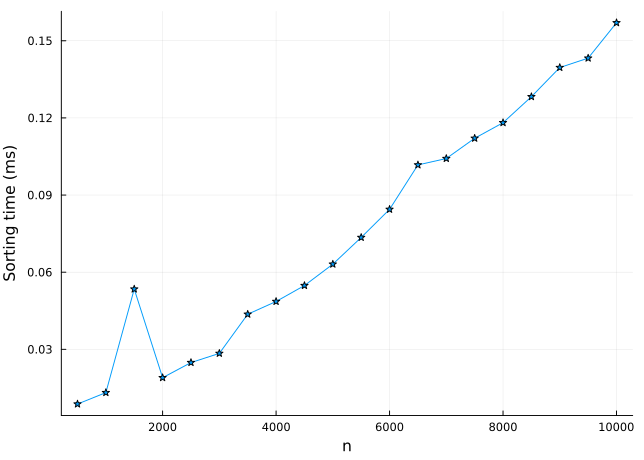

```julia
using Random, Plots
Random.seed!(0)

function do_timing()
   times = Vector{Float64}(undef,0)
   n_range = 500:500:10^4
   for n in n_range
      Random.seed!(0)
      data = rand(Int64,n)
      start_time = time_ns()
      sort!(data[1:n]) #Use the in-built sort! instead
      end_time = time_ns()
      push!(times, Int(end_time - start_time)/10^6) #time in milliseconds
   end
   return times, n_range
end

times, n_range = do_timing()
plot(n_range,times, xlabel="n", ylabel="Sorting time (ms)", shape = :star, legend = false)
```

Note that the running time appears to grow linearly but actually we will theoretically see soon that it is of order $n \log n$. In fact, there are multiple sorting algorithms that have $O(n \log n)$ complexity and it can even be proved that for arbitrary data you cannot do better than $O(n \log n)$ in terms of the number of comparisons.

We’ll explore one such “efficient” sorting algorithm, heap-sort, and this is because the heap data structure on which heap-sort is based will be with us for most of the course. heap-sort is not necessarily the best algorithm, and in fact when you call `sort!` in Julia, by default the quick-sort algorithm is used. See the actual source code in https://github.com/JuliaLang/julia/blob/master/base/sort.jl.

But first we discuss a few datastructures.

# 3 A Whirlwind tour of a Few Datastructures

Note: Do not confuse “Datastructures” with “Databases”, these are related terms that mean different things.

When we approach programming without thinking about it too much there is one simple datastructure, an **array**. An array is a list of a given length with random access to any point. For example,

```julia
data = [65, 51, 32, 12, 23, 84, 68, 1]
@show length(data)
@show data[4]; #the fourth element
```

```
length(data) = 8
data[4] = 12
```

Lookups in an array are $O(1)$ constant time. But other operations can be more costly. This is because an array spans adjacent memory cells and if we want to `insert!`, `push!`, or `prepend!` to it, then more memory often needs to be managed and the array often needs to be copied. Just to get an understanding of arrays, lets use `pointer` to get the address of an array and certain elements in it.

```julia
data = [65, 51, 32, 12, 23, 84, 68, 1]
@show eltype(data)
@show sizeof(eltype(data))
@show pointer(data)
@show pointer(data,1)
@show pointer(data,2)
@show pointer(data,length(data));

#This is true for any array
always_true = (pointer(data,length(data)) - pointer(data))/sizeof(eltype(data)) + 1 == length(data)
@show always_true;
```

```
eltype(data) = Int64
sizeof(eltype(data)) = 8
pointer(data) = Ptr{Int64}(0x00007d6500b1db80)
pointer(data, 1) = Ptr{Int64}(0x00007d6500b1db80)
pointer(data, 2) = Ptr{Int64}(0x00007d6500b1db88)
pointer(data, length(data)) = Ptr{Int64}(0x00007d6500b1dbb8)
always_true = true
```

In a classic datastructures course, you would often study the following data structures just after speaking about arrays:

- [Linked lists](https://en.wikipedia.org/wiki/Linked_list)
- Queues
- Stacks

We won’t do this thoroughly here due to lack of time (some of this material is taught in COMP3506 at UQ). You can see implementations of these datasturctures and others in DataStructures.jl.

We do consider a few of the key other [Collections and Datastructures](https://docs.julialang.org/en/v1/base/collections/) that Julia supplies. The key ones include:

- Multidimensional arrays (tensors)
- Dictionaries
- Sets

## 3.1 Multidimensional arrays

Multidimensional arrays are basically arrays where the indexing into the array is carried out in smarter way. The simplest example is a matrix.

```julia
m, n = 3, 5
data = Array{Int8,2}(undef,m,n)
N = n*m #Total size of data
for i in 1:N
   @show pointer(data,i)
   data[i] = i #even though data is a matrix, we can just go over the times sequentially.
end
data
```

```
pointer(data, i) = Ptr{Int8}(0x00007d65021c79e0)
pointer(data, i) = Ptr{Int8}(0x00007d65021c79e1)
pointer(data, i) = Ptr{Int8}(0x00007d65021c79e2)
pointer(data, i) = Ptr{Int8}(0x00007d65021c79e3)
pointer(data, i) = Ptr{Int8}(0x00007d65021c79e4)
pointer(data, i) = Ptr{Int8}(0x00007d65021c79e5)
pointer(data, i) = Ptr{Int8}(0x00007d65021c79e6)
pointer(data, i) = Ptr{Int8}(0x00007d65021c79e7)
pointer(data, i) = Ptr{Int8}(0x00007d65021c79e8)
pointer(data, i) = Ptr{Int8}(0x00007d65021c79e9)
pointer(data, i) = Ptr{Int8}(0x00007d65021c79ea)
pointer(data, i) = Ptr{Int8}(0x00007d65021c79eb)
pointer(data, i) = Ptr{Int8}(0x00007d65021c79ec)
pointer(data, i) = Ptr{Int8}(0x00007d65021c79ed)
pointer(data, i) = Ptr{Int8}(0x00007d65021c79ee)
```

```
3×5 Matrix{Int8}:
 1  4  7  10  13
 2  5  8  11  14
 3  6  9  12  15
```

As you can see, `data[i,j]` is just like `data[(j-1)*m + i]`:

```julia
for j in 1:n, i in 1:m
   @show data[i,j], data[(j-1)*m + i]
end
```

```
(data[i, j], data[(j - 1) * m + i]) = (1, 1)
(data[i, j], data[(j - 1) * m + i]) = (2, 2)
(data[i, j], data[(j - 1) * m + i]) = (3, 3)
(data[i, j], data[(j - 1) * m + i]) = (4, 4)
(data[i, j], data[(j - 1) * m + i]) = (5, 5)
(data[i, j], data[(j - 1) * m + i]) = (6, 6)
(data[i, j], data[(j - 1) * m + i]) = (7, 7)
(data[i, j], data[(j - 1) * m + i]) = (8, 8)
(data[i, j], data[(j - 1) * m + i]) = (9, 9)
(data[i, j], data[(j - 1) * m + i]) = (10, 10)
(data[i, j], data[(j - 1) * m + i]) = (11, 11)
(data[i, j], data[(j - 1) * m + i]) = (12, 12)
(data[i, j], data[(j - 1) * m + i]) = (13, 13)
(data[i, j], data[(j - 1) * m + i]) = (14, 14)
(data[i, j], data[(j - 1) * m + i]) = (15, 15)
```

Access of matrix elements is $O(1)$, however this doesn’t mean that in practice (certainly in big numerical computations), different ways of accesing the matrix vary:

```julia
function sum_rows(data, n, m)
   s = zero(eltype(data))
   for i in 1:n
      for j in 1:m
         s += data[i,j]
      end
   end
   return s
end

function sum_columns(data, n, m)
   s = zero(eltype(data))
   for j in 1:m
      for i in 1:n
         s += data[i,j]
      end
   end
   return s
end

using Random
Random.seed!(0)
n, m = 500, 10^6
data = rand(n,m)
#dry run for precompilation
sum_columns(data, n, m)
sum_rows(data, n, m)
println("Summing with the column iteration moving fastest")
@time sum_columns(data, n, m)
println("Summing with the row iteration moving fastest")
@time sum_rows(data, n, m);
```

```
Summing with the column iteration moving fastest
  0.298775 seconds (1 allocation: 16 bytes)
Summing with the row iteration moving fastest
  4.122017 seconds (1 allocation: 16 bytes)
```

As you can see, going by columns is much faster than going by rows. This is because there are many **cache misses** if we go by rows. The key takeaway here is that while the speed complexity of the array algorithm $O(1)$ does not capture actual clock speed because of computer architecture issues such as the cache.